# Brody Vogel COSC 455 Midterm

Brody Vogel

COSC 455

Midterm Exam

3.1

This is essentially linear contrast stretching.

Assuming an original pixel intensity in the image is represented by $I(x, y)$ and the original maximiumin and minimum intensitites in $I$ are $I_{min}$ and $I_{max}$, the transformation:

$T(x_{prime}, y_{prime}) = \frac{(L - 1) - 0}{I_{max} - I_{min}} \times (I(x, y) - I_{min})$

```
                                    =
```

$T(x_{prime}, y_{prime}) = \frac{L - 1}{I_{max} - I_{min}} \times (I(x, y) - I_{min})$

spreads the intensities of the image such that the lowest intensity is 0 and the highest is L - 1.

3.5 (b) Below, I'll first list the 4 bit planes, and then the representations of the numbers in fewer bits.

First, the full, 4-bit representations of the numbers:

$ \begin{bmatrix} 0(0000) & 1(0001) & 8(1000) & 6(0110) \\ 2(0010) & 2(0010) & 1(0001) & 1(0001) \\ 1(0001) & 15(1111) & 14(1110) & 12(1100) \\ 3(0011) & 6(0110) & 9(1001) & 10(1010) \end{bmatrix} $

1st (rightmost / least important) bit:

$ \begin{bmatrix} 0 & 1 & 0 & 0 \\ 0 & 0 & 1 & 1 \\ 1 & 1 & 0 & 0 \\ 1 & 0 & 1 & 0 \end{bmatrix} $

2nd bit:

$ \begin{bmatrix} 0 & 0 & 0 & 1 \\ 1 & 1 & 0 & 0 \\ 0 & 1 & 1 & 0 \\ 1 & 1 & 0 & 1 \end{bmatrix} $

3rd bit

$ \begin{bmatrix} 0 & 0 & 0 & 1 \\ 0 & 0 & 0 & 0 \\ 0 & 1 & 1 & 1 \\ 0 & 1 & 0 & 0 \end{bmatrix} $

4th bit

$ \begin{bmatrix} 0 & 0 & 1 & 0 \\ 0 & 0 & 0 & 0 \\ 0 & 1 & 1 & 1 \\ 0 & 0 & 1 & 1 \end{bmatrix} $

And now, the bit-by-bit representations of the data, as in bit masks (number and parenthetical bit representations):

4-bit:

$ \begin{bmatrix} 0 (0000) & 1 (0001) & 8 (1000) & 6 (0110) \\ 2 (0010 & 2 (0010) & 1 (0001) & 1 (0001) \\ 1 (0001) & 15 (1111) & 14 (1110) & 12 (1100) \\ 3 (0011) & 6 (0110) & 9 (1001) & 10 (1010) \end{bmatrix} $

3-bit:

$ \begin{bmatrix} 0 (000) & 0 (000) & 8 (100) & 6 (011) \\ 2 (001) & 2 (001) & 0 (000) & 0 (000) \\ 0 (000) & 14 (111) & 14 (111) & 12 (110) \\ 2 (001) & 6 (011) & 8 (100) & 10 (101) \end{bmatrix} $

2-bit:

$ \begin{bmatrix} 0 (00) & 0 (00) & 8 (10) & 4 (01) \\ 0 (00) & 0 (00) & 0 (00) & 0 (00) \\ 0 (00) & 12 (11) & 12 (11) & 12 (11) \\ 0 (00) & 4 (01) & 8 (10) & 8 (10) \end{bmatrix} $

1-bit:

$ \begin{bmatrix} 0 (0) & 0 (0) & 8 (1) & 0 (0) \\ 0 (0) & 0 (0) & 0 (0) & 0 (0) \\ 0 (0) & 8 (1) & 8 (1) & 8 (1) \\ 0 (0) & 0 (0) & 8 (1) & 8 (1) \end{bmatrix} $

3.24

Like the second example in Section 3.4, I'd pass the chip a toy unit image; let's say:

$ \begin{bmatrix} 0 & 0 & 0 & 0 & 0 \\ 0 & 0 & 0 & 0 & 0 \\ 0 & 0 & 1 & 0 & 0 \\ 0 & 0 & 0 & 0 & 0 \\ 0 & 0 & 0 & 0 & 0 \end{bmatrix} $

and a toy kernel:

$ \begin{bmatrix} 1 & 2 & 3 \\ 4 & 5 & 6 \\ 7 & 8 & 9 \end{bmatrix} $

The kernel must not be symmetric; if it were, convolution and correlation would produce the same result.

Correlation moves the center of the kernel over the image, computing the sum of products each time; so we'd expect - if the chip performed correlation - that the output would be (A):

$ \begin{bmatrix} 0 & 0 & 0 & 0 & 0 \\ 0 & 9 & 8 & 7 & 0 \\ 0 & 6 & 5 & 4 & 0 \\ 0 & 3 & 2 & 1 & 0 \\ 0 & 0 & 0 & 0 & 0 \end{bmatrix} $

Convolution does the same, but with a kernel rotated 180 degrees. So - if the chip performed convolution - we'd expect (B):

$ \begin{bmatrix} 0 & 0 & 0 & 0 & 0 \\ 0 & 1 & 2 & 3 & 0 \\ 0 & 4 & 5 & 6 & 0 \\ 0 & 7 & 8 & 9 & 0 \\ 0 & 0 & 0 & 0 & 0 \end{bmatrix} $

Thus, to test the chip, I'd pass it the toy unit image and kernel above and determine whether it was performing correlation or convolution by checking the output. If the output matched (A), it'd be performing correlation; if (B), it'd be performing convolution.

3.30

a) Yes, the kernel is separable.

$vw^{T} = \begin{bmatrix} 2 & 1 & 1 & 3 \\ 4 & 2 & 2 & 6 \\ 2 & 1 & 1 & 3 \end{bmatrix} $

$vw^{T}$ can be decomposed into two 1-D matrices: $v = \begin{bmatrix} 1 \\ 2 \\ 1 \end{bmatrix} $ and $w = \begin{bmatrix} 2 \\ 1 \\ 1 \\ 3 \end{bmatrix} $.

This is the definition of separability.

b) Let $w_{1} = \begin{bmatrix} 1 \\ 2 \end{bmatrix} $

and $w_{2} = \begin{bmatrix} 1 \\ 3 \\ 1 \end{bmatrix} $.

Then $w_{1} \times w_{2}^{T} = \begin{bmatrix} 1 & 3 & 1 \\ 2 & 6 & 2 \end{bmatrix} $

and we're done.

c) Let $w_{1} = \begin{bmatrix} 1 \\ 2 \\ 1 \end{bmatrix} $

and $w_{2} = \begin{bmatrix} 2 \\ 1 \\ 1 \\ 3 \end{bmatrix} $.

Then $w_{1} \times w_{2}^{T} = \begin{bmatrix} 2 & 1 & 1 & 3\\ 4 & 2 & 2 & 6 \\ 2 & 1 & 1 & 3 \end{bmatrix} $

and we're done.

3.34

a) The histograms of the blurred images would no longer be equal. The box filter blurs horizontal and vertical lines. Applied to these images, then, there'd be more variance in the values actually in the box filter when we pass it over the checkered image (more unique combinations of numbers of black and white pixels); whereas, with the paneled image, there are only a few unique combinations of numbers of black and white pixels that will ever be in the box filter. So, in the new histrograms, the smoothed checkered image would have more unique values in the area between the lightest and darkest intensities.

b) My hypothesis is borne out in the plots below: the histogram for the blurred paneled image only has a few unique values, while that for the checkered image has many more.

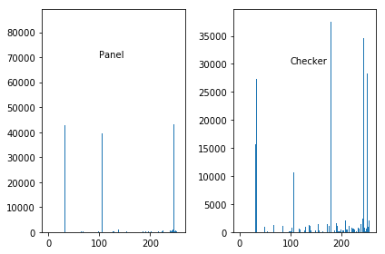

```python
import skimage
from skimage import io
from matplotlib import pyplot as plt
import numpy as np
import scipy.ndimage as ndi
import copy

%matplotlib inline

checkered = io.imread('/Users/brodyvogel/Desktop/checker.png')
paneled = io.imread('/Users/brodyvogel/Desktop/panel.png')

# apply the filters
new_checkered = ndi.filters.uniform_filter(checkered, size = 3)
new_paneled = ndi.filters.uniform_filter(paneled, size = 3)

# plot the new histograms
fig, ax = plt.subplots(1, 2)

plt.subplot(1, 2, 1)
plt.text(100, 70000, 'Panel')
plt.hist(new_paneled.flatten(), bins = 256, range = (0, 255))
plt.subplot(1, 2, 2)
plt.text(100, 30000, 'Checker')
plt.hist(new_checkered.flatten(), bins = 256, range = (0, 255))
plt.tight_layout()
plt.show()
```

3.39

Let the intensity values of the orignial image be represented by $p_{1}, p_{2},...,p_{n}$, where $n$ is the number of pixels in the image.

The sum of the pixels in the original image, then, is $\sum_{j = 1}^{n}{1 \times p_{j}}$.

Now, let the coefficients in the kernel be represented by $c_{1}, c_{2},...,c_{m}$ where $m$ is the number of coefficients in the kernel and $\sum_{i = 1}^{m}{c_{i}} = 1$.

Now, each pixel in $p_{1}, p_{2},...,p_{n}$ will be in each position $1,2,...,m$ of the kernel exactly once. Because $\sum_{i = 1}^{m}{c_{i}} = 1$, then, we know the total input of any $p_{j}$ to the sum of pixel values in the new filtered image is $\sum_{i = 1}^{m}{c_{i} \times p_{j}} = 1 \times p_{j}$.

So the sum of the pixel values in the new filtered image is $\sum_{j = 1}^{n}\sum_{i = 1}^{m}{c_{i} \times p_{j}} = \sum_{j = 1}^{n}{1 \times p_{j}}$, which is the same as in the original image, and we're done.

3.44

The bars merge in the image blurred with the 25x25 kernel because there are identical values in the kernel as it passes over most of the pixels in that part of the image.

The bars are 5 pixels wide, and there are 20 pixels between each bar. So, from the center of one bar to the next, there are 25 pixels. Using a 23x23 or 45x45 kernel, then, the ratio of black pixels to white pixels in the kernel changes as it passes over the part of the image with bars, which is the reason the resulting images retain differing intensity values and separation between the bars. Using a 25x25 kernel, though, the ratio of black pixels to white pixels in the kernel is the same for all interior points in the section of the image with bars (demonstrated below), which causes the resulting image to have identical intensity values and lose separation between the bars.

Let $b$s represent points with dark intensity and $w$s represent points with light intesity, and let an undeline represent a point currently in the kernel:

Iteration i) $www\underline{bbbbbwwwwwwwwwwwwwwwwwwww}bbbbb$

Iteration j) $wwwb\underline{bbbbwwwwwwwwwwwwwwwwwwwwb}bbbb$

As can be seen, when one black pixel leaves the kernel, another one is picked up on the other side of the white space, so the distribution of black pixels to white pixels remains constant in the 25x25 kernel.

3.57

If an image is supposed to be sharper, that means we're trying to highlight the contrasts; i.e., the kernel of the filter used by the system should have both positive and negative values that sum to 0, and, in turn, the output image should also have pixel values that sum to 0. If an image that's supposed to have been "sharpened" by the imaging system does not have pixel values that sum to 0, then, I'd conclude the system isn't working correctly.

If an image is supposed to be smoother, on the other hand, that means we're trying to downplay contrasts; i.e., the values in the kernel of the filter used by the system should sum to 1, and, in turn, the intensity values in the output image should have the same sum as those of the input image. If the intensity values of an image that's supposed to have been "smoothed" by the imaging system do not sum to the same value as those of the input image, then, I'd conclude the system isn't working correctly.

Project 3.5

a) The function for performing 2-D convolution of image f and kernel w:

```python
# helper function to map the input intensity values to [0, 1]
    # basic normalizing formula: (x_i - input_min)/(input_max - input_min)
def intScaling4e(f):
    # find min and max intensities
    high_val = np.max(f)
    low_val = np.min(f)
    # apply the formula to the flattenedarray
    normalized = np.array([(x - low_val)/(high_val - low_val) for x in f.flatten()])
    # reshape the array of normalized intensity values to the original shape
    f = normalized.reshape((f.shape[0], f.shape[1]))
    # return that matrix
    return(f)

# function, from scratch, for performing convolution with any sized filter
def twodConv4e(f, w, turn_off_scaling = False):
    # option to turn off the normalizing; checks if option was turned on
    if turn_off_scaling == False:
        f = intScaling4e(f)

    # rotate the input kernel 180 degrees - that is,
        # make it a convolution instead of a correlation
    w = np.rot90(w, 2)
    # make everything a copy, just to be safe
    new_img = copy.deepcopy(f)

    # determine how many replicate-padded rows and columns to add to
    # the original image so the filter can pass over it
    x_num_pad = int(np.floor(w.shape[0]/2))
    y_num_pad = int(np.floor(w.shape[1]/2))

    x_rep_pad_top = np.array([f[0, :],] * x_num_pad)
    x_rep_pad_bottom = np.array([f[f.shape[0]-1, :],] * x_num_pad)

    # create the replicated-padded image by stacking the extra
    # rows and columns onto the original image
    f = np.vstack((x_rep_pad_top, f))
    f = np.vstack((f, x_rep_pad_bottom))

        # have to transpose these so the stack plays nice
    y_rep_pad_left = np.array([f[:, 0],] * y_num_pad).T
    y_rep_pad_right = np.array([f[:, f.shape[1]-1],] * y_num_pad).T

    f = np.hstack((y_rep_pad_left, f))
    f = np.hstack((f, y_rep_pad_right))

    # here's where we pass the filter over the image
        # x index for the point in the new image
    new_x = 0
        # loop over all the x-values in the original image
        # that we need to compute new values for (i.e., those
        # that aren't the new replicate-padded rows)
    for x in range(x_num_pad, f.shape[0]-x_num_pad):
        # y index for the point in the new image
        new_y = 0
        # loop over all the y-values in the original image
        # that we need to compute new values for (i.e., those
        # that aren't the new replicate-padded columns)
        for y in range(y_num_pad, f.shape[1]-y_num_pad):
            # now we can compute the actual intensity values from the filter
                # this slices into the original image and gets the neighborhood of points
                # that will contribute to the intensity of the pixel in the new
                # image
            mat1 = f[(x-x_num_pad):(x+x_num_pad+1), (y-y_num_pad):(y+y_num_pad+1)]
                # this assigns the pixel in the new image the sum of the
                # weights in the filter multiplied by the relevant points in the
                # neighborhood of the pixel in the original image
            new_img[new_x, new_y] = np.multiply(w, mat1).sum()
        # updates for the loops
            new_y += 1
        new_x += 1
    # and return the new image
    return(new_img)
```

The first function above normalizes the intesity values in the familiar way. I then rotate the passed filter 180 degrees so as to perform convolution and not correlation. My function then uses replicate padding to add enough rows and columns around the edges of the original image to allow the filter to work on those edge pixels. The function then loops over every pixel in the original image, each time extracting the appropriately-sized neighborhood thereof and performing element-wise multiplication of that sliced matrix and the passed-in filter; the corresponding pixel in the new image is then set to the sum of this matrix product.

b)

To check that my function is actually performing convolution, I built a 151x151 kernel. First, I made sure my kernel was not symmetric about its center; if it were, it'd be impossible to tell if it were performing correlation or convolution. Next, I set all the values in the bottom half of my kernel to .7 and all those in the top half to .2.

Let my *rotated* kernel, w, be represented by:

$ \begin{bmatrix} .7 & .7 & .7 \\ .2 & .2 & .2 \\ .2 & .2 & .2 \end{bmatrix} $

and the unit image to be filtered, f, be:

$ \begin{bmatrix} 0 & 0 & 0 \\ 0 & 1 & 0 \\ 0 & 0 & 0 \end{bmatrix} $ .

The output, then, should be:

$ \begin{bmatrix} .2 & .2 & .2 \\ .2 & .2 & .2 \\ .7 & .7 & .7 \end{bmatrix} $

(remembering values closer to 0 are darker).

As this tiny example demonstrates, if my function is working, it should produce a plot with a square in the center that has a dark top half and bright bottom half.

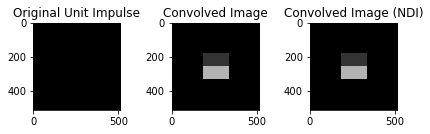

```python
# make the 512x512 unit image
unit = np.zeros((512, 512))
unit[256, 256] = 1

# make a 151x151 kernel so the results are visible
my_kernel = np.zeros((151, 151))
# make the top half brighter
my_kernel[76:, :] = .7
# make the bottom half darker
my_kernel[0:76, :] = .2

# to show
fig, ax = plt.subplots(1, 3)

# plot the original unit image
plt.subplot(1, 3, 1)
plt.title("Original Unit Impulse")
plt.imshow(unit, cmap = 'gray', vmin = 0, vmax = 1)

# perform the convolution with my function
convolved = twodConv4e(unit, my_kernel)
# show the results
plt.subplot(1, 3, 2)
plt.title("Convolved Image")
plt.imshow(convolved, cmap = 'gray', vmin = 0, vmax = 1)

# test that my function is working correctly with ndi
# compute the convolution using the built-in method
test_convolved = ndi.convolve(unit, my_kernel)
# show the results
plt.subplot(1, 3, 3)
plt.title("Convolved Image (NDI)")
plt.imshow(test_convolved, cmap = 'gray', vmin = 0, vmax = 1)
# make it pretty
plt.tight_layout()
```

I think my function is proved to be correctly performing convolution; as hoped, it produces a square in the center of the plot with a dark top half and brighter bottom half. I also used the ".convolve" function from ndimage to see if it produced the same result as my function; it did, and that seems like further proof that my function is working.